# Density Estimation - Chicago Crimes

Zhi Rong Tan

### Part 1

Chicago crime data is available at https://data.cityofchicago.org/Public-Safety/Crimes-Map/dfnk-7re6. The dataset contains information on the reported incidents of crime that have occurred in the City of Chicago over the past year.

First, let us explore a one-dimensional density for each of the two continuous variables LATITUDE and LONGITUDE using a kernel density estimator.

```r
library(dplyr)
data1.raw <- read.csv("crimes2.csv")
data2.raw = filter(data1.raw, !is.na(LATITUDE))
data1 = filter(data1.raw, !is.na(LONGITUDE))

lat <- data1$LATITUDE
long <- data1$LONGITUDE
```

Let us use the K-Fold cross validation to determine the optimal bandwidth. We shall employ the Gaussian kernel estimation
$$\hat{f}(x) = \frac{1}{nh}\sum^n_{i=1}K(\frac{x-X_i}{h})$$
where Kernel is given by
$$K(z) = \frac{1}{\sqrt{2\pi}}exp(-z^2/2)$$

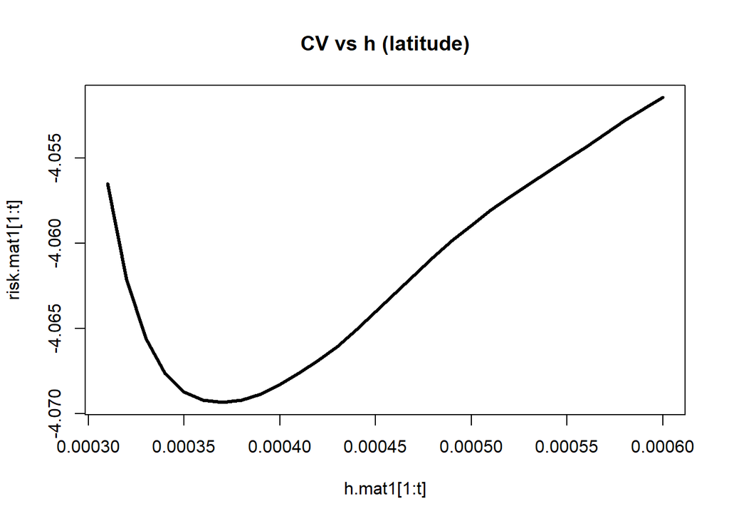

```r
#First, let us set up the parameters for cross validation.
#FIRST, we look at Latitude
n = length(lat)
t = 30
k = 20
risk.mat1 = vector(length = t)
h.mat1 = c(0.00001*(31:60))
folds = createFolds(lat, k = k)

for (i in 1:t){
  h = h.mat1[i]
  modela <- density(lat, bw = h, kernel = 'gaussian')
  sum.part <- integrate.xy(modela$x, (modela$y)^2)

  k.fold.part <- 0
  for (j in 1:k){
    train.set = lat[-folds[[j]]]
    modelb <- density(train.set, bw = h, kernel = 'gaussian')
    app.dense <- approxfun(modelb$x, modelb$y)
    k.fold.part = k.fold.part + mean(app.dense(lat[folds[[j]]]))
  }
  risk.score <- sum.part - (2/k)*k.fold.part
  risk.mat1[i] <- risk.score
}
plot(h.mat1[1:t], risk.mat1[1:t], type = 'l', lwd = 3, main = 'CV vs h (latitude)')
```

```r
index1 = which.min(risk.mat1)
h.mat1[index1]
```

```
## [1] 0.00037
```

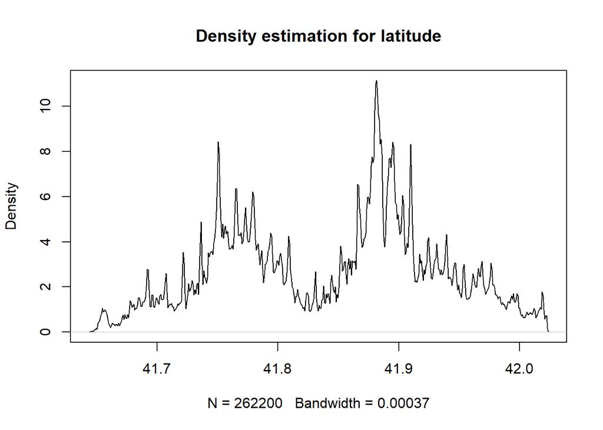

```r
optbw.lat = h.mat1[index1]
density.1b <- density(lat, bw=optbw.lat, kernel="gaussian")
plot(density.1b, main='Density estimation for latitude')
```

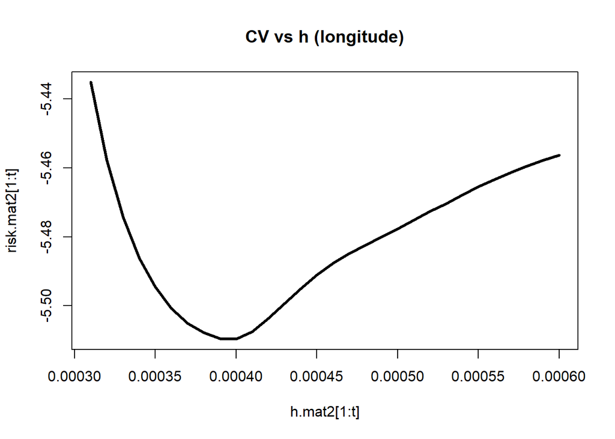

```r
#########################################
#########################################
#Next, let us look at longitude

n = length(long)
t = 30
k = 30
risk.mat2 = vector(length = t)
h.mat2 = c(0.00001*(31:60))
folds = createFolds(long, k = k)

for (i in 1:t){
  h = h.mat2[i]
  modela <- density(long, bw = h, kernel = 'gaussian')
  sum.part <- integrate.xy(modela$x, (modela$y)^2)

  k.fold.part <- NULL
  for (j in 1:k){
    train.set = long[-folds[[j]]]
    test.set = long[folds[[j]]]
    modelb <- density(train.set, bw = h, kernel = 'gaussian')
    app.dense <- approxfun(modelb$x, modelb$y)
    a = app.dense(test.set)
    a[which(is.na(a))] <- 0
    k.fold.part = c(k.fold.part, mean(a))
  }
  risk.score <- sum.part - (2*mean(k.fold.part))
  risk.mat2[i] <- risk.score
}
plot(h.mat2[1:t], risk.mat2[1:t], type = 'l', lwd = 3, main = 'CV vs h (longitude)')
```

```r
index2 = which.min(risk.mat2)
h.mat2[index2]
```

```
## [1] 0.0004
```

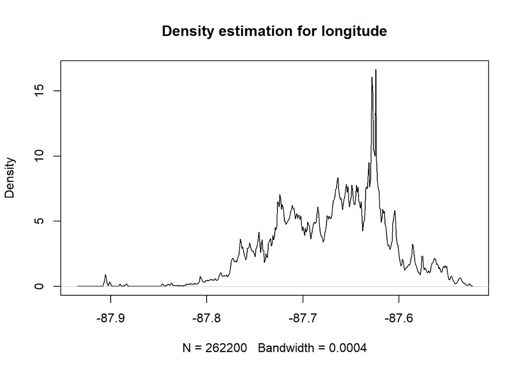

```r
optbw.long = h.mat2[index2]
density.1a <- density(long, bw=optbw.long, kernel="gaussian")
plot(density.1a, main="Density estimation for longitude")
```

## Part 2

```r
data1.raw <- read.csv("crimes2.csv")
data2.raw = filter(data1.raw, !is.na(LATITUDE))
data1 = filter(data1.raw, !is.na(LONGITUDE))

lat <- data1$LATITUDE
long <- data1$LONGITUDE
```

We will determine the optimal bandwidth h, for each dimension, with the following formula:
$$h_* = 1.06\hat{\sigma}n^{-1/5}$$
$$\hat{\sigma} = min(s, IQR/1.34)$$
where s is the sample standard deviation and IQR is the interquartile range.

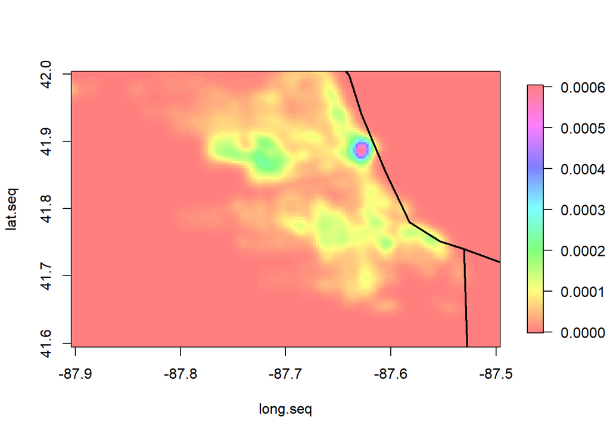

```r
#Find the optimal h by the Normal Reference Rule.
#LONGITUDE
iqr.long = IQR(long)/1.34
iqr.lat = IQR(lat)/1.34
sd.long = sqrt(var(long))
sd.lat = sqrt(var(lat))
sigma.long = min(iqr.long,sd.long)
sigma.lat = min(iqr.lat,sd.lat)
h.long = 1.06*sigma.long*(length(long))^(-1/5)
h.lat = 1.06*sigma.lat*(length(lat))^(-1/5)

#Next create the 2D grid.
long.seq = seq(-87.9-h.long/2, -87.5+h.long/2, 0.0025)
lat.seq = seq(41.6-h.lat/2, 42+h.lat/2, 0.0035)

#Write the kernel function for density estimation
gaussian = function (x,y,xi,yi,hx,hy){
  1/(2*pi)*exp((-1/2)*(((x-xi)/hx)^2+((y-yi)/hy)^2))
}

estimate.mat = function(xmat, ymat, xi, yi, hx, hy) {
  n = length(xi)
  length.xseq=length(xmat)
  length.yseq=length(ymat)
  pred.matrix = matrix(0, length.xseq, length.yseq)
  for (i in 1:length.xseq) {
    for (j in 1:length.yseq) {
      subset <- which((xi-xmat[i])^2+(yi-ymat[j])^2 <= 10*(hx^2+hy^2))
      small.xi = xi[subset]
      small.yi = yi[subset]
      kernel = gaussian(xmat[i],ymat[j],small.xi,small.yi,hx,hy)
      pred = sum(kernel)/(hx*hy*n^2)
      pred.matrix[i,j] <- pred
    }
  }
  pred.matrix
}

library(fields)
final.result <- estimate.mat(long.seq, lat.seq, long, lat, h.long, h.lat)
image.plot(long.seq, lat.seq, final.result, col=rainbow(128, alpha=.5))
US(add=T, lwd=2, col=1)
```